# In class R Practice with linear models

April 29, 2025

In this tutorial we run code to simulate the process of building the least squares regression line from $n$ data points
$$(x_1, y_1), (x_2, y_2), \ldots, (x_n,
y_n)$$

under the assumption that $X$ and $Y$ are related by a simple linear model
$$Y = aX + b + \epsilon,$$
and we assume $\epsilon$ is normally distributed with mean 0 and standard deviation $\sigma$.

**1.** Choose your model by assigning values to `a`, `b`, and `sigma`. Make sure `sigma` is greater than 0. Also choose `n`, the size of the sample you will generate.

```r
a = 10
b = 5
sigma = 4
n = 45
```

**2.** Create a vector of `n` random $x$-values between 0 and 10:

```r
x = runif(n,0,10)
```

**3.** Create a vector of `n` random errors using `rnorm(n,0,sigma)`, and then the corresponding $y$-values from the $x$ vector using your linear model

```r
epsilon = rnorm(n,0,sigma)
y = a*x + b + epsilon
```

**4.** Make a point plot of $x$ vs $y$. Also find the correlation coefficient between $x$ and $y$ to measure the strength and direction of the linear relationship.

**5.** Repeat questions 1-4 by first changing `n` a few times, and then by changing `sigma` a few times. How does the correlation coefficient tend to change if you (a) change `n`; (b) change `sigma`?

**6.** Build the least squares regression model, call it fit:

```r
fit <- lm(y~x)
```

**7.** Look at the model summary. What are the regression coefficients $\hat{a}$ and $\hat{b}$? Are they exactly equal to the values of $a$ and $b$ you choose? Close?

```r
summary(fit)
```

```
##
## Call:
## lm(formula = y ~ x)
##
## Residuals:
##     Min      1Q  Median      3Q     Max
## -9.4341 -1.7091 -0.0162  1.7611 12.0684
##
## Coefficients:
##             Estimate Std. Error t value Pr(>|t|)
## (Intercept)   7.0927     1.2252   5.789 7.41e-07 ***
## x             9.7207     0.2151  45.183  < 2e-16 ***
## ---
## Signif. codes:  0 '***' 0.001 '**' 0.01 '*' 0.05 '.' 0.1 ' ' 1
##
## Residual standard error: 4.16 on 43 degrees of freedom
## Multiple R-squared:  0.9794, Adjusted R-squared:  0.9789
## F-statistic:  2042 on 1 and 43 DF,  p-value: < 2.2e-16
```

**9.** Is there statistically significant evidence from the data that `b` is not 0?

**10.** Your regression object `fit` has lots of information, including

Make a residual plot for your model. Be sure to include a dashed horizontal line at the 0 residual mark.

Here’s one approach:

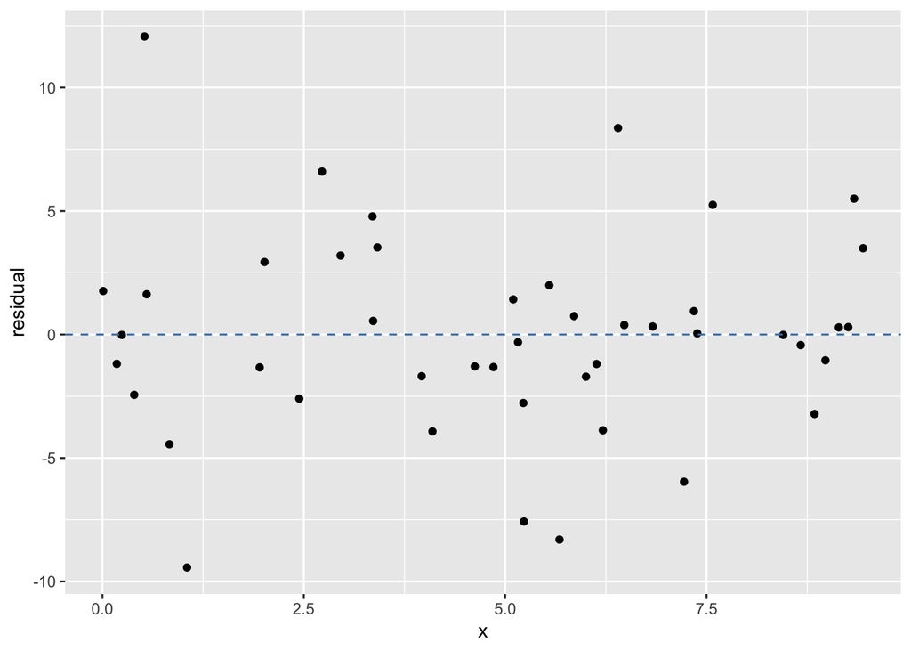

```r
library(tidyverse)
df <- fit$model |>
  mutate(residual = fit$residuals)

ggplot(df,aes(x = x, y = residual))+
  geom_point()+
  geom_hline(yintercept = 0,
             linetype = 'dashed',
             col = 'steelblue')
```

Does the residual plot reveal any red flags that a linear model is not appropriate here?